# Lab 5 - Insurance Costs

Author

Kelly Ohata

```python
import pandas as pd
import numpy as np
from plotnine import *
```

## 1 Part One: Data Exploration

```python
myData =  pd.read_csv("https://www.dropbox.com/s/bocjjyo1ehr5auz/insurance_costs_1.csv?dl=1")
myData = pd.get_dummies(myData, columns = ["sex","smoker"],drop_first=True)
myData["sex_male"] = myData["sex_male"].astype(int)
myData["smoker_yes"] = myData["smoker_yes"].astype(int)
myData["smoker_label"] = myData["smoker_yes"].map({0:"No", 1:"Yes"})
myData["sex_label"] = myData["sex_male"].map({0: "Female", 1: "Male"})

myData = myData.dropna()
```

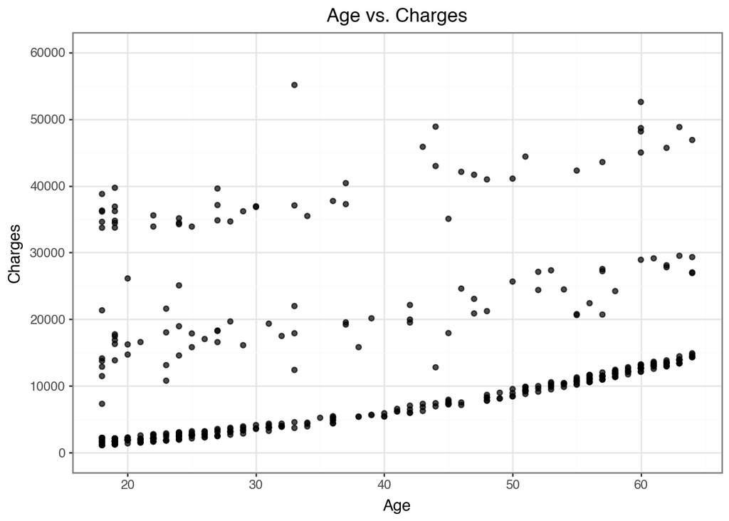

```python
# Scatter Plot - Age vs Charges
(
    ggplot(myData, aes(x="age", y="charges"))
    +geom_point(alpha = 0.7)
    +labs(title = "Age vs. Charges", x = "Age", y = "Charges")
    +scale_y_continuous(name="Charges", limits = (0,60000), breaks = range(0,60001,10000))
    +theme_bw()
)
```

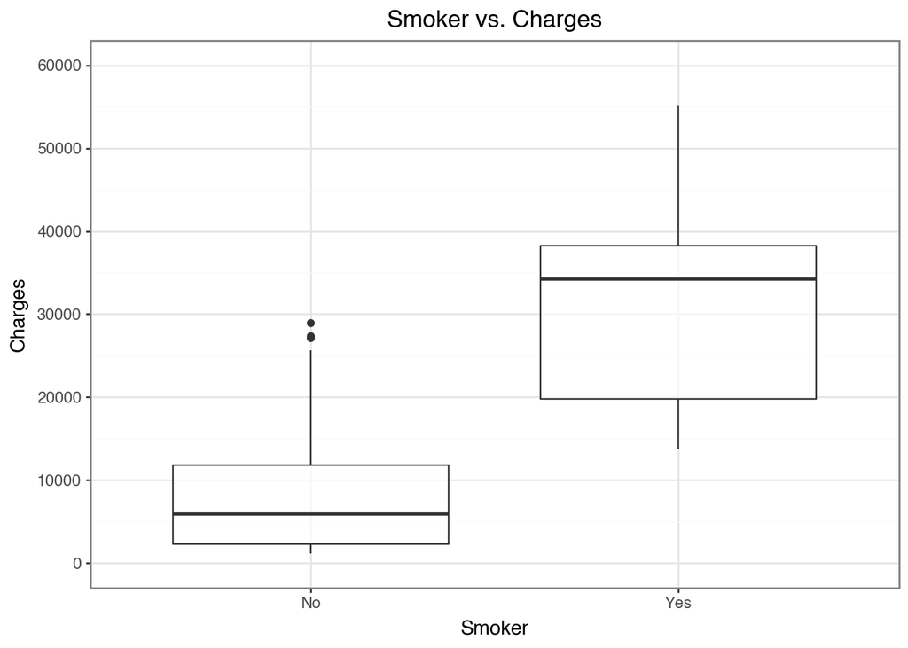

```python
# Box Plot - Smoker vs Chargers
(
    ggplot(myData, aes(x="smoker_label", y="charges"))
    +geom_boxplot(alpha = 0.7)
    +labs(title = "Smoker vs. Charges", x = "Smoker", y = "Charges")
    +scale_y_continuous(name="Charges", limits = (0,60000), breaks = range(0,60001,10000))
    +theme_bw()
)
```

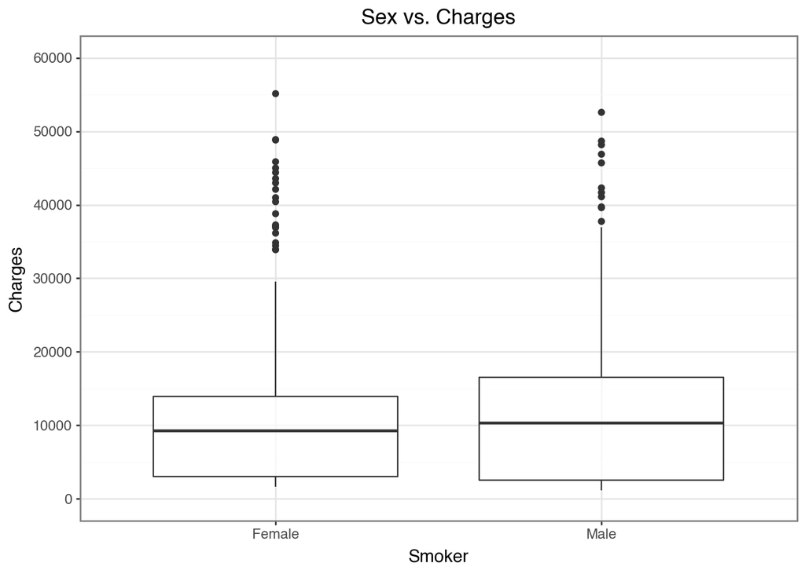

```python
# Box Plot - Sex vs Charges

(
    ggplot(myData, aes(x="sex_label", y="charges"))
    +geom_boxplot(alpha = 0.7)
    +labs(title = "Sex vs. Charges", x = "Smoker", y = "Charges")
    +scale_y_continuous(name="Charges", limits = (0,60000), breaks = range(0,60001,10000))
    +theme_bw()
)
```

## 2 Part Two: Simple Linear Models

```python
from sklearn.linear_model import LinearRegression
from sklearn.metrics import mean_squared_error
```

```python
# Model 1: Charges ~ Age
x1 = myData[["age"]]
y = myData["charges"]

m1 = LinearRegression()
m1.fit(x1,y)

y1_predict = m1.predict(x1)

print("Model 1 Intercept: ",m1.intercept_ )
print("Model 1 Slope: ", m1.coef_)
print("Model 1 R^2:", m1.score(x1,y))
print("Model 1 MSE: ",mean_squared_error(y,y1_predict))
```

```
Model 1 Intercept:  3611.758798507106
Model 1 Slope:  [228.79904937]
Model 1 R^2: 0.09938105452062707
Model 1 MSE:  126739267.91026388
```

```python
# Model 2: Charges ~ Age + Sex
x2 = myData[["age","sex_male"]]
y = myData["charges"]

m2 = LinearRegression()
m2.fit(x2,y)

y2_predict = m2.predict(x2)

print("Model 2 - Charges ~ Age + Sex")
print("Model 2 Intercept: ",m2.intercept_ )
print("Model 2 Slope: ", m2.coef_)
print("Model 2 R^2:", m2.score(x2,y))
print("Model 2 MSE: ",mean_squared_error(y,y2_predict))
```

```
Model 2 - Charges ~ Age + Sex
Model 2 Intercept:  3315.3323465342655
Model 2 Slope:  [228.42586236 649.83258997]
Model 2 R^2: 0.10012952499706396
Model 2 MSE:  126633939.67937087
```

```python
# Model 3:  Charges ~ Age + Smoker
x3 = myData[["age","smoker_yes"]]
y = myData["charges"]

m3 = LinearRegression()
m3.fit(x3,y)

y3_predict = m3.predict(x3)

print("Model 3 - Charges ~ Age + Smoker")
print("Model 3 Intercept: ",m3.intercept_ )
print("Model 3 Slope: ", m3.coef_)
print("Model 3 R^2:", m3.score(x3,y))
print("Model 3 MSE: ",mean_squared_error(y,y3_predict))
```

```
Model 3 - Charges ~ Age + Smoker
Model 3 Intercept:  -2166.852295375431
Model 3 Slope:  [  253.14535549 24048.86743795]
Model 3 R^2: 0.7603842948069404
Model 3 MSE:  33719831.46524373
```

Model 3 provdes a better fit for the data compared to Model 2 because Model 3 has a greater R-squared and a lower MSE.

## 3 Part Three: Multiple Linear Models

```python
# Model 4: Charges ~ Age + BMI
from sklearn.metrics import r2_score
x4 = myData[["age","bmi"]]
y = myData["charges"]

m4 = LinearRegression()
m4.fit(x4,y)

y4_predict = m4.predict(x4)

print("Model 4 - Charges ~ Age + BMI")
print("Model 4 Intercept: ",m4.intercept_ )
print("Model 4 Slope: ", m4.coef_)
print("Model 4 R^2:", m4.score(x4,y))
print("Model 4 MSE: ",mean_squared_error(y,y4_predict))
```

```
Model 4 - Charges ~ Age + BMI
Model 4 Intercept:  -4627.533445708479
Model 4 Slope:  [216.29721472 283.20380126]
Model 4 R^2: 0.12032144234129338
Model 4 MSE:  123792439.58129103
```

```python
# Model 5: Charges ~ Age + Age^2
myData["age^2"] = myData["age"]**2
x5 = myData[["age","age^2"]]
y = myData["charges"]

m5 = LinearRegression()
m5.fit(x5,y)

y5_predict = m5.predict(x5)

print("Model 5 - Charges ~ Age + Age^2")
print("Model 5 Intercept: ",m5.intercept_ )
print("Model 5 Slope: ", m5.coef_)
print("Model 5 R^2:", m5.score(x5,y))
print("Model 5 MSE: ",mean_squared_error(y,y5_predict))
```

```
Model 5 - Charges ~ Age + Age^2
Model 5 Intercept:  2299.730568726698
Model 5 Slope:  [308.42816984  -1.00150889]
Model 5 R^2: 0.09958694669946933
Model 5 MSE:  126710293.80956802
```

There’s no change in the R^2 between Model 5 (Age + Age^2) and Model 1 (Age) and only a slight change in the MSE.

```python
# Model 6: Polynomial Model of Degree 4
from sklearn.preprocessing import PolynomialFeatures
degree4 = PolynomialFeatures(degree=4, include_bias=False)

x6_degree4 = degree4.fit_transform(myData[["age"]])
y = myData["charges"]

m6 = LinearRegression()
m6.fit(x6_degree4,y)

y6_predict = m6.predict(x6_degree4)

print("Model 6 - Charges ~ Age Polynomial Model of Degree 4")
print("Model 6 Intercept: ",m6.intercept_ )
print("Model 6 Slope: ", m6.coef_)
print("Model 6 R^2:", m6.score(x6_degree4,y))
print("Model 6 MSE: ",mean_squared_error(y,y6_predict))
```

```
Model 6 - Charges ~ Age Polynomial Model of Degree 4
Model 6 Intercept:  68637.89783245522
Model 6 Slope:  [-7.94841022e+03  3.58110163e+02 -6.47905090e+00  4.12933982e-02]
Model 6 R^2: 0.10782931453183742
Model 6 MSE:  125550389.64569834
```

The R^2 of Model 6 (Age - Polynomial Model of Degree 4) changed from 0.099 to 0.108 and the MSE lowered to 125 million from 126 million.

```python
# Model 7: Polynomial Model of Degree 12
degree12 = PolynomialFeatures(degree=12, include_bias=False)

x7_degree12 = degree12.fit_transform(myData[["age"]])
y = myData["charges"]

m7 = LinearRegression()
m7.fit(x7_degree12,y)

y7_predict = m7.predict(x7_degree12)

print("Model 7 - Charges ~ Age Polynomial Model of Degree 12")
print("Model 7 Intercept: ",m7.intercept_ )
print("Model 7 Slope: ", m7.coef_)
print("Model 7 R^2:", m7.score(x7_degree12,y))
print("Model 7 MSE: ",mean_squared_error(y,y7_predict))
```

```
Model 7 - Charges ~ Age Polynomial Model of Degree 12
Model 7 Intercept:  7722.308179851927
Model 7 Slope:  [ 1.11576244e-17  5.02954431e-14  1.78141366e-14  5.21213760e-13
  1.33165430e-11  2.88763668e-10  4.86792508e-09  4.93848760e-08
 -3.05862710e-09  7.07651716e-11 -7.24805911e-13  2.77079487e-15]
Model 7 R^2: 0.10734541968551126
Model 7 MSE:  125618485.56892622
```

The R^2 of Model 7 (Age - Polynomial Model of Degree 12) went from 0.099 to 0.107 and the MSE went down to 125 million from 126 million.

Based on the MSE and R-Squared values, Model 4 (Age + BMI) is the best model compared to the other models, but it is not necessarily the best model overall.

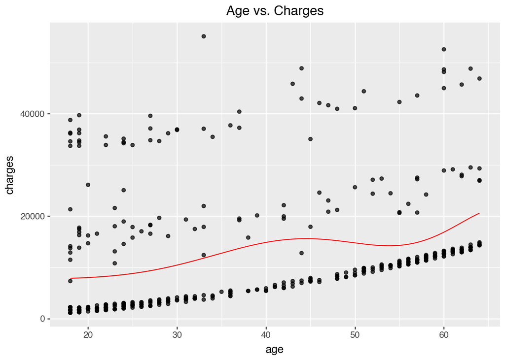

```python
age_range = np.linspace(myData["age"].min(), myData["age"].max(), 250)
age_range = pd.DataFrame({"age": np.linspace(myData["age"].min(), myData["age"].max(), 250)})
age_range_degree12 = degree12.fit_transform(age_range)
age_range["charges_predictions"] = m7.predict(age_range_degree12)


(
    ggplot(myData, aes(x="age",y="charges"))
    +geom_point(alpha=0.7)
    +geom_line(age_range, aes(x="age",y="charges_predictions"), color = "red")
    +labs(title = "Age vs. Charges")
)
```

## 4 Part Four: New data

```python
myData2 = pd.read_csv("https://www.dropbox.com/s/sky86agc4s8c6qe/insurance_costs_2.csv?dl=1")
myData2 = pd.get_dummies(myData2, columns = ["sex","smoker"],drop_first=True)
myData2["sex_male"] = myData2["sex_male"].astype(int)
myData2["smoker_yes"] = myData2["smoker_yes"].astype(int)
myData2["smoker_label"] = myData2["smoker_yes"].map({0:"No", 1:"Yes"})
myData2["sex_label"] = myData2["sex_male"].map({0: "Female", 1: "Male"})

myData2 = myData2.dropna()
```

```python
#New Model 1 - Charges ~ Age
x1 = myData[["age"]]
y = myData["charges"]

new_x1 = myData2[["age"]]
new_y = myData2["charges"]

new_m1 = LinearRegression()
new_m1.fit(x1,y)

y1_predict = new_m1.predict(new_x1)

print("New Model 1 - Charges ~ Age")
print("New Model 1 Intercept: ",new_m1.intercept_ )
print("New Model 1 Slope: ", new_m1.coef_)
print("New Model 1 R^2:", new_m1.score(x1,y))
print("New Model 1 MSE: ",mean_squared_error(new_y,y1_predict))
```

```
New Model 1 - Charges ~ Age
New Model 1 Intercept:  3611.758798507106
New Model 1 Slope:  [228.79904937]
New Model 1 R^2: 0.09938105452062707
New Model 1 MSE:  136077136.50195494
```

```python
#New Model 2 - Charges ~ Age + BMI
x2 = myData[["age","bmi"]]
y = myData["charges"]

new_x2 = myData2[["age","bmi"]]
new_y = myData2["charges"]

new_m2 = LinearRegression()
new_m2.fit(x2,y)

y2_predict = new_m2.predict(new_x2)

print("New Model 2 - Charges ~ Age + BMI")
print("New Model 2 Intercept: ",new_m2.intercept_ )
print("New Model 2 Slope: ", new_m2.coef_)
print("New Model 2 R^2:", new_m2.score(x2,y))
print("New Model 2 MSE: ",mean_squared_error(new_y,y2_predict))
```

```
New Model 2 - Charges ~ Age + BMI
New Model 2 Intercept:  -4627.533445708479
New Model 2 Slope:  [216.29721472 283.20380126]
New Model 2 R^2: 0.12032144234129338
New Model 2 MSE:  132636406.1108129
```

```python
#New Model 3 - Charges ~ Age + BMI + Smoker
x3 = myData[["age","bmi","smoker_yes"]]
y = myData["charges"]

new_x3 = myData2[["age","bmi","smoker_yes"]]
new_y = myData2["charges"]

new_m3 = LinearRegression()
new_m3.fit(x3,y)

y3_predict = new_m3.predict(new_x3)

print("New Model 3 - Charges ~ Age + BMI + Smoker")
print("New Model 3 Intercept: ",new_m3.intercept_ )
print("New Model 3 Slope: ", new_m3.coef_)
print("New Model 3 R^2:", new_m3.score(x3,y))
print("New Model 3 MSE: ",mean_squared_error(new_y,y3_predict))
```

```
New Model 3 - Charges ~ Age + BMI + Smoker
New Model 3 Intercept:  -10350.082987156035
New Model 3 Slope:  [  240.72164671   281.31845364 24043.82827651]
New Model 3 R^2: 0.7810467724680946
New Model 3 MSE:  35377541.24141632
```

```python
#New Model 4 - Charges ~ (Age + BMI): Smoker
myData["age_smoker"] = myData["age"] * myData["smoker_yes"]
myData["bmi_smoker"] = myData["bmi"] * myData["smoker_yes"]

myData2["age_smoker"] = myData2["age"] * myData2["smoker_yes"]
myData2["bmi_smoker"] = myData2["bmi"] * myData2["smoker_yes"]

x4 = myData[["age_smoker","bmi_smoker"]]
y = myData["charges"]

new_x4 = myData2[["age_smoker","bmi_smoker"]]
new_y = myData2["charges"]

new_m4 = LinearRegression()
new_m4.fit(x4,y)

y4_predict = new_m4.predict(new_x4)

print("New Model 4 - Charges ~ (Age + BMI): Smoker")
print("New Model 4 Intercept: ",new_m4.intercept_ )
print("New Model 4 Slope: ", new_m4.coef_)
print("New Model 4 R^2:", new_m4.score(x4,y))
print("New Model 4 MSE: ",mean_squared_error(new_y,y4_predict))
```

```
New Model 4 - Charges ~ (Age + BMI): Smoker
New Model 4 Intercept:  7307.023657911383
New Model 4 Slope:  [107.05762116 677.00833574]
New Model 4 R^2: 0.7253050837740997
New Model 4 MSE:  47626025.35814418
```

```python
#New Model 5 - Charges ~ (Age + BMI) * Smoker
x5 = myData[["age","bmi","smoker_yes","age_smoker","bmi_smoker"]]
y = myData["charges"]

new_x5 = myData2[["age","bmi","smoker_yes","age_smoker","bmi_smoker"]]
new_y = myData2["charges"]

new_m5 = LinearRegression()
new_m5.fit(x5,y)

y5_predict = new_m5.predict(new_x5)

print("New Model 5 - Charges ~ (Age + BMI) * Smoker")
print("New Model 5 Intercept: ",new_m5.intercept_ )
print("New Model 5 Slope: ", new_m5.coef_)
print("New Model 5 R^2:", new_m5.score(x5,y))
print("New Model 5 MSE: ",mean_squared_error(new_y,y5_predict))
```

```
New Model 5 - Charges ~ (Age + BMI) * Smoker
New Model 5 Intercept:  -2524.685690083981
New Model 5 Slope:  [ 2.58179772e+02  5.36117114e+00 -2.09937051e+04 -1.24532947e+01
  1.48116585e+03]
New Model 5 R^2: 0.8672991020173331
New Model 5 MSE:  21786256.86685256
```

Based on the MSE and the R-squared values of each model, the best model that fits the data best is Model 5 because it has the highest R-squared value of 0.867 and the lowest MSE of 21.8 million.

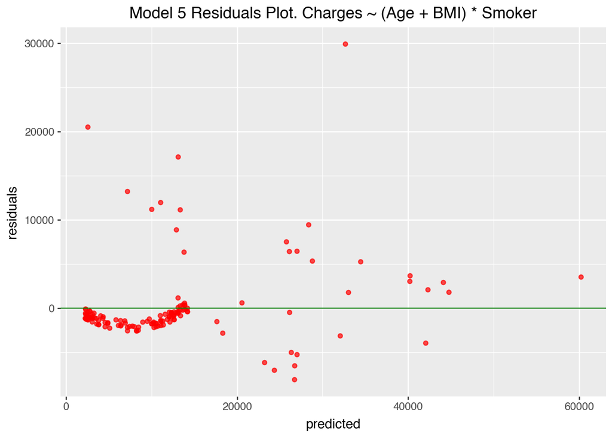

```python
myData2["predicted"] = new_m5.predict(new_x5)
myData2["residuals"] = myData2["charges"] - myData2["predicted"]

(
    ggplot(myData2, aes(x="predicted",y="residuals"))
    +geom_point(alpha = 0.7 ,color= "red")
    +geom_hline(yintercept=0, color = "green")
    +labs(title = "Model 5 Residuals Plot. Charges ~ (Age + BMI) * Smoker")
)
```

## 5 Part Five: Full Exploration

```python
myData["age_smoker"] = myData["age"] * myData["smoker_yes"]
myData["bmi_smoker"] = myData["bmi"] * myData["smoker_yes"]

myData2["age_smoker"] = myData2["age"] * myData2["smoker_yes"]
myData2["bmi_smoker"] = myData2["bmi"] * myData2["smoker_yes"]


models = {
    "Model 1": ["age"],
    "Model 2": ["age", "bmi"],
    "Model 3": ["age", "bmi", "smoker_yes"],
    "Model 4": ["age_smoker", "bmi_smoker"],
    "Model 5": ["age", "bmi", "smoker_yes", "age_smoker", "bmi_smoker"]
}

rows = []

for name, Xcols in models.items():
    X_train = myData[Xcols]
    y_train = myData["charges"]

    X_test = myData2[Xcols]
    y_test = myData2["charges"]

    model = LinearRegression().fit(X_train, y_train)
    y_pred = model.predict(X_test)

    test_mse = mean_squared_error(y_test, y_pred)
    test_r2 = r2_score(y_test, y_pred)

    myData2[f"{name}_predict"] = y_pred

    rows.append({
        "Model": name,
        "Test MSE": test_mse,
        "Test R²": test_r2
    })

test_error = pd.DataFrame(rows)
test_error
```

|  | Model | Test MSE | Test R² |
| --- | --- | --- | --- |
| 0 | Model 1 | 1.360771e+08 | 0.122365 |
| 1 | Model 2 | 1.326364e+08 | 0.144556 |
| 2 | Model 3 | 3.537754e+07 | 0.771831 |
| 3 | Model 4 | 4.762603e+07 | 0.692834 |
| 4 | Model 5 | 2.178626e+07 | 0.859489 |

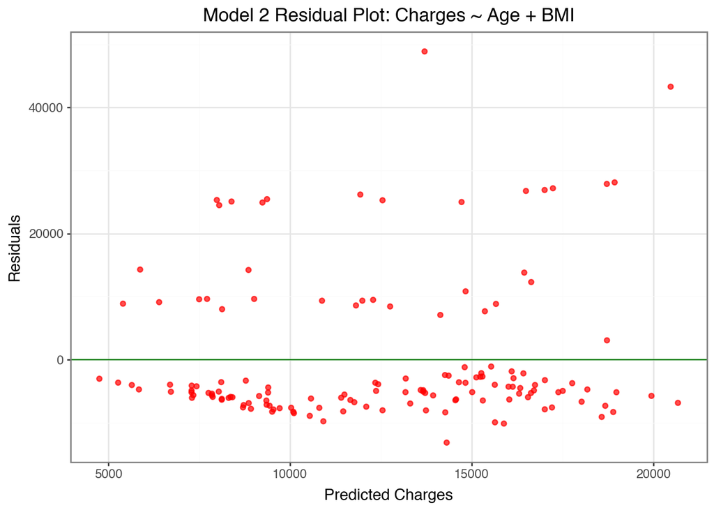

```python
X2_train = myData[["age", "bmi"]]
y2_train = myData["charges"]

X2_test = myData2[["age", "bmi"]]
y2_test = myData2["charges"]

model2 = LinearRegression().fit(X2_train, y2_train)

myData2["predicted_model2"] = model2.predict(X2_test)
myData2["residuals_model2"] = myData2["charges"] - myData2["predicted_model2"]

(
    ggplot(myData2, aes(x="predicted_model2", y="residuals_model2"))
    + geom_point(alpha=0.7, color="red")
    + geom_hline(yintercept=0, color="green")
    + labs(
        title="Model 2 Residual Plot: Charges ~ Age + BMI",
        x="Predicted Charges",
        y="Residuals"
    )
    + theme_bw()
)
```